# Testing for Cointegration

## Data Access

This case study uses prices of soybean oil and diesel fuel from [Nasdaq](https://data.nasdaq.com/). You will need to create an account to download the data in R (or Python) using the [`{Quandl}`](https://data.nasdaq.com/tools/r) package. After you create your account, you can simply search for the price series of interest (e.g., Soybean Oil Futures or U.S. No. 2 Diesel Retail Prices) and click the R (or Python) link on the right hand side of the window below Libraries. A pop up will appear containing the code for you to copy and paste into your software, as shown in Figure 1.

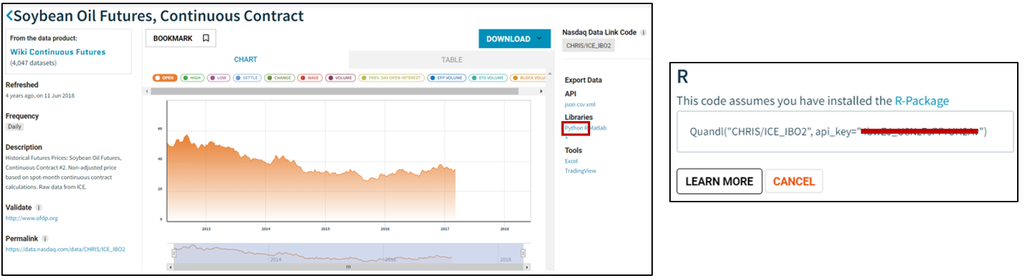

Figure 1: Nasdaq interface

## Loading the data into R

We first load the packages we will use to analyze the data.

```r
pacman::p_load(tidyverse, lubridate, stringr, Quandl, urca, xts, forecast)
```

Then we will load the data using the R codes we have copied from Nasdaq.

```r
soybeans <- Quandl("CHRIS/ICE_IBO2")
diesel <- Quandl("EIA/PET_EMD_EPD2D_PTE_NUS_DPG_W")
```

A quick look at the data shows that the soybean oil price is reported for each working day, excluding holidays from May 2012 to June 2018, and the diesel price is reported every Monday. There are different techniques proposed in the literature to work with multiple time series data that are sampled at different frequencies. To keep things simple, we will use `Quandl`’s weekly function to aggregate the daily data to weekly average prices for the soybeans series. Because the soybean weekly dates will land on Sundays, we will add one day so that the dates for the two price series will be on Mondays.

```r
# get soybeans data in weekly format
soybeans <- Quandl("CHRIS/ICE_IBO2", collapse = "weekly")

# add 1 day to date, so dates will be on Monday instead of Sunday
soybeans$Date <- soybeans$Date + 1

# get diesel data for the similar time period
diesel <- Quandl("EIA/PET_EMD_EPD2D_PTE_NUS_DPG_W", start_date = "2012-05-13", end_date = "2018-06-17")
```

We have to tell R that we are working with time series data. There are [multiple packages](https://faculty.washington.edu/ezivot/econ424/Working%20with%20Time%20Series%20Data%20in%20R.pdf) to handle time series data in R. In our labs, we will use the `{xts}` package. With this package, we will use the `xts` function to convert the dataframe to an xts object. The syntax is `xts(data, order.by = date_index)`.

```r
ts_soy <- xts(soybeans$Settle, order.by = soybeans$Date)
ts_diesel <- xts(diesel$Value, order.by = diesel$Date)
```

Now that these two xts objects have the same dates, we can use the `xts.merge()` function.

```r
soydiesel <- merge.xts(ts_soy, ts_diesel)
colnames(soydiesel) <- c("p_soy", "p_diesel")
head(soydiesel)
```

```
##            p_soy p_diesel
## 2012-05-14 52.45    4.004
## 2012-05-21 50.54    3.956
## 2012-05-28 50.34    3.897
## 2012-06-04 48.81    3.846
## 2012-06-11 49.67    3.781
## 2012-06-18 48.62    3.729
```

# Working with time series data

When working with time series data, the first step is to test for stationarity. If we run OLS with non-stationariy data, we get spurious results. An exception to this rule is when two data series are cointegrated. Two non-stationarity series are cointegrated if there exists a linear combination of the two series that is stationarity. This linear combination is called the cointegrating vector.

This case study tests the cointegration for soybean oil and diesel because the literature suggests there is a long run price linkage between these two variables (read [here](https://www.ideals.illinois.edu/bitstream/handle/2142/45274/Hala_Zahran.pdf?sequence=1)

## Testing for Stationarity

We use the `ur.df()` function of the `{urca}` package to conduct the Dickey-Fuller Unit Root test.

```r
df_soy <- ur.df(soydiesel$p_soy, type = c("trend"), lags = 0)

df_diesel <- ur.df(soydiesel$p_diesel, type = c("trend"), lags = 0)

summary(df_soy)
```

```
##
## ###############################################
## # Augmented Dickey-Fuller Test Unit Root Test #
## ###############################################
##
## Test regression trend
##
##
## Call:
## lm(formula = z.diff ~ z.lag.1 + 1 + tt)
##
## Residuals:
##     Min      1Q  Median      3Q     Max
## -2.6758 -0.5355 -0.0669  0.5812  3.4167
##
## Coefficients:
##               Estimate Std. Error t value Pr(>|t|)
## (Intercept)  0.9536023  0.5774461   1.651   0.0997 .
## z.lag.1     -0.0229758  0.0118392  -1.941   0.0532 .
## tt          -0.0010135  0.0009794  -1.035   0.3015
## ---
## Signif. codes:  0 '***' 0.001 '**' 0.01 '*' 0.05 '.' 0.1 ' ' 1
##
## Residual standard error: 0.9782 on 314 degrees of freedom
## Multiple R-squared:  0.0139, Adjusted R-squared:  0.007623
## F-statistic: 2.214 on 2 and 314 DF,  p-value: 0.111
##
##
## Value of test-statistic is: -1.9407 1.999 2.2136
##
## Critical values for test statistics:
##       1pct  5pct 10pct
## tau3 -3.98 -3.42 -3.13
## phi2  6.15  4.71  4.05
## phi3  8.34  6.30  5.36
```

```r
summary(df_diesel)
```

```
##
## ###############################################
## # Augmented Dickey-Fuller Test Unit Root Test #
## ###############################################
##
## Test regression trend
##
##
## Call:
## lm(formula = z.diff ~ z.lag.1 + 1 + tt)
##
## Residuals:
##       Min        1Q    Median        3Q       Max
## -0.134995 -0.020726 -0.004536  0.018837  0.148265
##
## Coefficients:
##               Estimate Std. Error t value Pr(>|t|)
## (Intercept) -3.252e-02  1.930e-02  -1.685   0.0929 .
## z.lag.1      5.244e-03  4.624e-03   1.134   0.2576
## tt           8.517e-05  3.410e-05   2.498   0.0130 *
## ---
## Signif. codes:  0 '***' 0.001 '**' 0.01 '*' 0.05 '.' 0.1 ' ' 1
##
## Residual standard error: 0.035 on 314 degrees of freedom
## Multiple R-squared:  0.02447,    Adjusted R-squared:  0.01825
## F-statistic: 3.938 on 2 and 314 DF,  p-value: 0.02047
##
##
## Value of test-statistic is: 1.1341 3.0927 3.9375
##
## Critical values for test statistics:
##       1pct  5pct 10pct
## tau3 -3.98 -3.42 -3.13
## phi2  6.15  4.71  4.05
## phi3  8.34  6.30  5.36
```

In the Dickey-Fuller test of soybean oil prices, we observe that the t-statistic is -1.94. We compare this number to the tau3 critical values of [-3.98, -3.42, -3.13] at the 1%, 5%, and 10% level, respectively. Because the t-statistic is larger than all of the critical values, we fail to reject the null hypothesis of a unit root at any significance level.

In the Dickey-Fuller test of diesel prices, the t-statistic is 1.13. We compare this number to the tau3 critical values of [-3.98, -3.42, -3.13] at the 1%, 5%, and 10% level, respectively. Because the t-statistic is larger than all of the critical values, we fail to reject the null hypothesis of a unit root at any significance level.

Based from the Dickey-Fuller tests, we conclude that both soybean oil and diesel prices are non-stationary.

## Testing for I(1)

We now test whether the first difference of each series is stationary. We can only proceed with a test of cointegration if the non-stationary data series are both integrated of the same order.

We use the `diff.xts()` function to take the first difference. We add in `na.pad = F` to drop the first row, which will be `NA`. The `ur.df()` function only works if the data does not include any NAs.

```r
df_soy_diff <- ur.df(diff.xts(soydiesel$p_soy, na.pad = F), type = c("trend"), lags = 0)

df_diesel_diff <- ur.df(diff.xts(soydiesel$p_diesel, na.pad = F), type = c("trend"), lags = 0)

summary(df_soy_diff)
```

```
##
## ###############################################
## # Augmented Dickey-Fuller Test Unit Root Test #
## ###############################################
##
## Test regression trend
##
##
## Call:
## lm(formula = z.diff ~ z.lag.1 + 1 + tt)
##
## Residuals:
##     Min      1Q  Median      3Q     Max
## -2.5816 -0.5579 -0.0892  0.5626  3.2501
##
## Coefficients:
##               Estimate Std. Error t value Pr(>|t|)
## (Intercept) -0.1229728  0.1108962  -1.109    0.268
## z.lag.1     -0.9963355  0.0562737 -17.705   <2e-16 ***
## tt           0.0003799  0.0006054   0.628    0.531
## ---
## Signif. codes:  0 '***' 0.001 '**' 0.01 '*' 0.05 '.' 0.1 ' ' 1
##
## Residual standard error: 0.9804 on 313 degrees of freedom
## Multiple R-squared:  0.5004, Adjusted R-squared:  0.4972
## F-statistic: 156.8 on 2 and 313 DF,  p-value: < 2.2e-16
##
##
## Value of test-statistic is: -17.7052 104.5127 156.7666
##
## Critical values for test statistics:
##       1pct  5pct 10pct
## tau3 -3.98 -3.42 -3.13
## phi2  6.15  4.71  4.05
## phi3  8.34  6.30  5.36
```

```r
summary(df_diesel_diff)
```

```
##
## ###############################################
## # Augmented Dickey-Fuller Test Unit Root Test #
## ###############################################
##
## Test regression trend
##
##
## Call:
## lm(formula = z.diff ~ z.lag.1 + 1 + tt)
##
## Residuals:
##       Min        1Q    Median        3Q       Max
## -0.070906 -0.014826 -0.002322  0.011746  0.146070
##
## Coefficients:
##               Estimate Std. Error t value Pr(>|t|)
## (Intercept) -3.508e-03  3.117e-03  -1.125    0.261
## z.lag.1     -3.727e-01  4.395e-02  -8.480 9.06e-16 ***
## tt           1.736e-05  1.701e-05   1.021    0.308
## ---
## Signif. codes:  0 '***' 0.001 '**' 0.01 '*' 0.05 '.' 0.1 ' ' 1
##
## Residual standard error: 0.02729 on 313 degrees of freedom
## Multiple R-squared:  0.1869, Adjusted R-squared:  0.1817
## F-statistic: 35.98 on 2 and 313 DF,  p-value: 8.633e-15
##
##
## Value of test-statistic is: -8.4796 23.9859 35.9771
##
## Critical values for test statistics:
##       1pct  5pct 10pct
## tau3 -3.98 -3.42 -3.13
## phi2  6.15  4.71  4.05
## phi3  8.34  6.30  5.36
```

The Dickey-Fuller test on the first difference of soybean oil and diesel prices show that the test statistics are -17.71 and -8.48, respectively. Comparing the test statistics to the critical values of [-3.98, -3.42, -3.13] at the 1%, 5%, and 10%, respectively. We reject the null hypothesis of a unit root for both price series. We therefore conclude that both series are integrated of order 1. We can now proceed with the test for cointegration.

## Engle-Granger Test

The first step involves estimating the cointegrating vector $\alpha$ and $\beta$ in the equation $p^{soy} = \alpha + \beta p^{diesel} + \epsilon$.

```r
reg_nosubsidy <- lm(p_soy ~ p_diesel, data = soydiesel)
summary(reg_nosubsidy)
```

```
##
## Call:
## lm(formula = p_soy ~ p_diesel, data = soydiesel)
##
## Residuals:
##     Min      1Q  Median      3Q     Max
## -10.832  -3.421  -0.313   3.565  11.963
##
## Coefficients:
##             Estimate Std. Error t value Pr(>|t|)
## (Intercept)  10.1142     1.3158   7.687 1.92e-13 ***
## p_diesel      8.6151     0.4054  21.249  < 2e-16 ***
## ---
## Signif. codes:  0 '***' 0.001 '**' 0.01 '*' 0.05 '.' 0.1 ' ' 1
##
## Residual standard error: 4.871 on 316 degrees of freedom
## Multiple R-squared:  0.5883, Adjusted R-squared:  0.587
## F-statistic: 451.5 on 1 and 316 DF,  p-value: < 2.2e-16
```

[Theory](https://www.ideals.illinois.edu/bitstream/handle/2142/45274/Hala_Zahran.pdf?sequence=1) suggests that $\beta = 8.702$. Our regression results show that our estimated coefficient is 8.62, which is very close to the technical pricing relationship.

There was a long-running $1/gallon subsidy on biodiesel production that ended in the U.S. in early 2018. Theory suggests that the end of this subsidy should reduce the price of soybean oil by an amount which is less than $1/gallon of biodiesel, as the price reduction will depend on supply and demand elasticities.

We re-estimate our regression but include a subsidy dummy variable that equals 1 from the first week of January 2018 onwards. To refer to the date variable of our time series, we use the `index()` function.

```r
# create end of subsidy variable
soydiesel$subsidy <- ifelse(index(soydiesel) >= "2018-01-01", 1, 0)

# re-estimate regression
reg_subsidy <- lm(p_soy ~ p_diesel + subsidy, data = soydiesel)
summary(reg_subsidy)
```

```
##
## Call:
## lm(formula = p_soy ~ p_diesel + subsidy, data = soydiesel)
##
## Residuals:
##      Min       1Q   Median       3Q      Max
## -11.1753  -3.0293  -0.0664   3.1271  11.6115
##
## Coefficients:
##             Estimate Std. Error t value Pr(>|t|)
## (Intercept)  10.7240     1.2709   8.438 1.19e-15 ***
## p_diesel      8.5452     0.3901  21.903  < 2e-16 ***
## subsidy      -5.1390     0.9951  -5.164 4.29e-07 ***
## ---
## Signif. codes:  0 '***' 0.001 '**' 0.01 '*' 0.05 '.' 0.1 ' ' 1
##
## Residual standard error: 4.685 on 315 degrees of freedom
## Multiple R-squared:  0.6204, Adjusted R-squared:  0.618
## F-statistic: 257.4 on 2 and 315 DF,  p-value: < 2.2e-16
```

The results show that the estimated coefficient on the diesel price $\beta$ is stable, highly significant, and consistent with the theoretical estimate of 8.702. The subsidy dummy variable is also strongly significant. One caveat is that the number of weeks with the subsidy is quite short due to the data we have, so including this variable may not be a good identification strategy.

The second step of the Engle-Granger test is to collect the residuals from the previous regression and run a Dickey-Fuller test for a unit root. If we reject the null hypothesis of a unit root, we can conclude that soybean oil and diesel prices are cointegrated and the $\beta$ coefficient we estimated earlier has a meaningful interpretation. We can access the residuals using `residuals()` function and store them as new objects.

```r
# collect residuals of regression with no subsidy
resid_nosubsidy <- residuals(reg_nosubsidy)

# collect residuals of regression with subsidy
resid_subsidy <- residuals(reg_subsidy)
```

Next, we run a Dickey Fuller test on the residuals. As mentioned in the lecture, we should not use a time trend, and we should restrict the intercept to zero because residuals will have a zero mean, so we will use `type = c("none")` instead of `type = c("trend")`.

```r
df_resid_nosubsidy <- ur.df(resid_nosubsidy, type = c("none"), lags = 0)
df_resid_subsidy <- ur.df(resid_subsidy, type = c("none"), lags = 0)

summary(df_resid_nosubsidy)
```

```
##
## ###############################################
## # Augmented Dickey-Fuller Test Unit Root Test #
## ###############################################
##
## Test regression none
##
##
## Call:
## lm(formula = z.diff ~ z.lag.1 - 1)
##
## Residuals:
##     Min      1Q  Median      3Q     Max
## -3.0271 -0.6434 -0.1190  0.5611  3.2477
##
## Coefficients:
##         Estimate Std. Error t value Pr(>|t|)
## z.lag.1 -0.02090    0.01138  -1.837   0.0671 .
## ---
## Signif. codes:  0 '***' 0.001 '**' 0.01 '*' 0.05 '.' 0.1 ' ' 1
##
## Residual standard error: 0.9815 on 316 degrees of freedom
## Multiple R-squared:  0.01057,    Adjusted R-squared:  0.007436
## F-statistic: 3.375 on 1 and 316 DF,  p-value: 0.06713
##
##
## Value of test-statistic is: -1.8371
##
## Critical values for test statistics:
##       1pct  5pct 10pct
## tau1 -2.58 -1.95 -1.62
```

```r
summary(df_resid_subsidy)
```

```
##
## ###############################################
## # Augmented Dickey-Fuller Test Unit Root Test #
## ###############################################
##
## Test regression none
##
##
## Call:
## lm(formula = z.diff ~ z.lag.1 - 1)
##
## Residuals:
##     Min      1Q  Median      3Q     Max
## -3.0752 -0.6532 -0.1020  0.5470  4.9593
##
## Coefficients:
##         Estimate Std. Error t value Pr(>|t|)
## z.lag.1 -0.02758    0.01225  -2.252    0.025 *
## ---
## Signif. codes:  0 '***' 0.001 '**' 0.01 '*' 0.05 '.' 0.1 ' ' 1
##
## Residual standard error: 1.018 on 316 degrees of freedom
## Multiple R-squared:  0.01579,    Adjusted R-squared:  0.01268
## F-statistic:  5.07 on 1 and 316 DF,  p-value: 0.02503
##
##
## Value of test-statistic is: -2.2517
##
## Critical values for test statistics:
##       1pct  5pct 10pct
## tau1 -2.58 -1.95 -1.62
```

We can also do an Augmented Dickey-Fuller test on the residuals. We can use the autocorrelation and partial autocorrelation plots to guide our decision on the number of lags to specify in the Augmented Dickey-Fuller test. We use the `Acf()` and `Pacf()` functions in the [`{forecast}`](https://cran.r-project.org/web/packages/forecast/forecast.pdf) package.

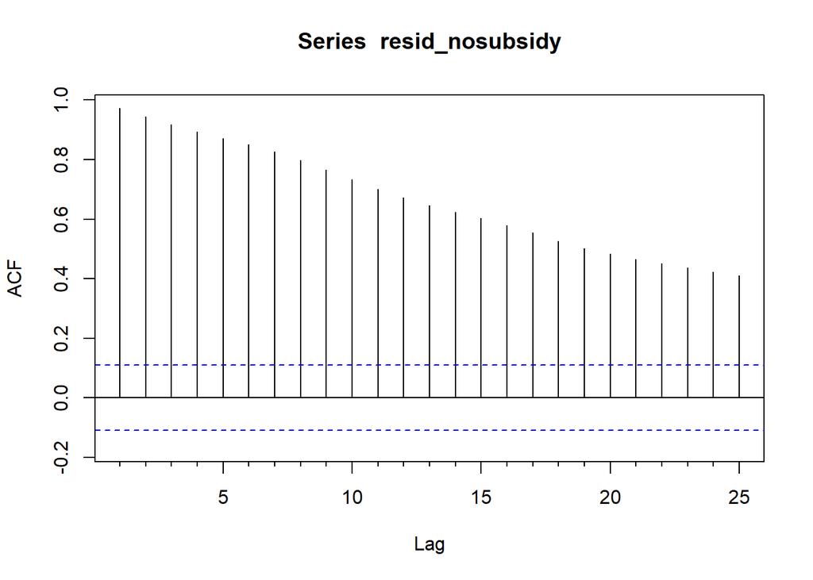

```r
Acf(resid_nosubsidy)
```

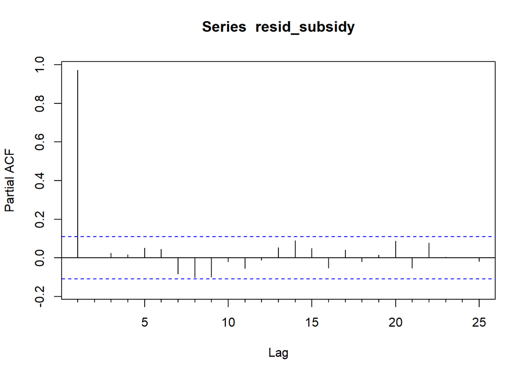

```r
Pacf(resid_subsidy)
```

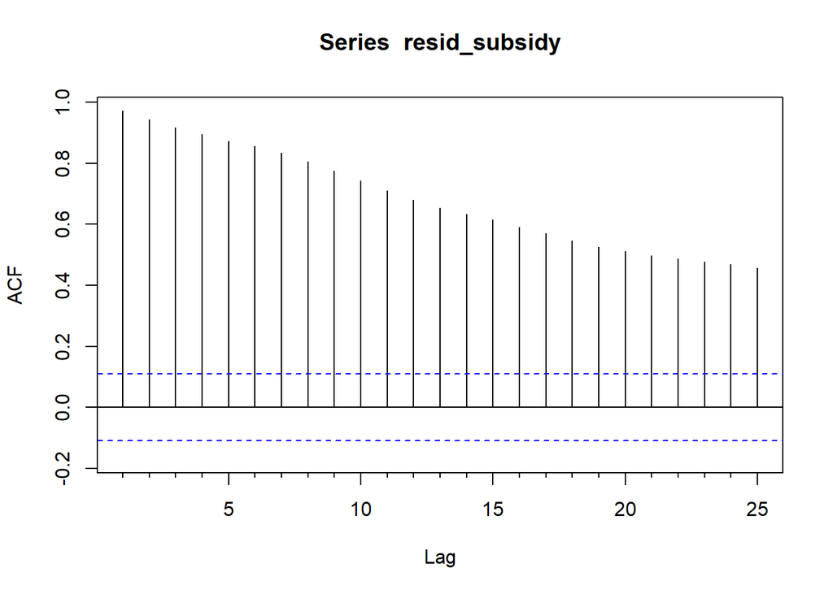

```r
Acf(resid_subsidy)
```

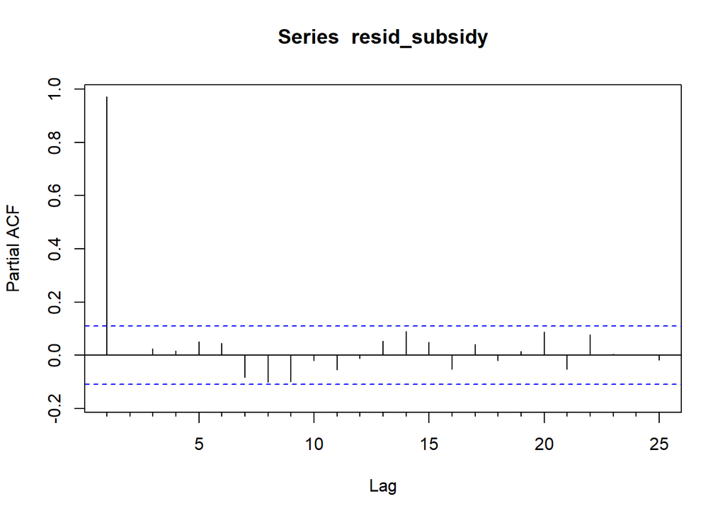

```r
Pacf(resid_subsidy)
```

We now proceed with an ADF test on the residuals. We do not have a time trend or an intercept, but we now include one lag in the model.

```r
adf_resid_nosubsidy <- ur.df(resid_nosubsidy, type = c("none"), lags = 1, selectlags = c("BIC"))

adf_resid_subsidy <- ur.df(resid_subsidy, type = c("none"), lags = 1, selectlags = c("BIC"))

summary(adf_resid_nosubsidy)
```

```
##
## ###############################################
## # Augmented Dickey-Fuller Test Unit Root Test #
## ###############################################
##
## Test regression none
##
##
## Call:
## lm(formula = z.diff ~ z.lag.1 - 1 + z.diff.lag)
##
## Residuals:
##     Min      1Q  Median      3Q     Max
## -3.1023 -0.6271 -0.0911  0.5624  3.2049
##
## Coefficients:
##            Estimate Std. Error t value Pr(>|t|)
## z.lag.1    -0.02014    0.01148  -1.754   0.0804 .
## z.diff.lag  0.03224    0.05624   0.573   0.5669
## ---
## Signif. codes:  0 '***' 0.001 '**' 0.01 '*' 0.05 '.' 0.1 ' ' 1
##
## Residual standard error: 0.9812 on 314 degrees of freedom
## Multiple R-squared:  0.01021,    Adjusted R-squared:  0.003907
## F-statistic:  1.62 on 2 and 314 DF,  p-value: 0.1996
##
##
## Value of test-statistic is: -1.7542
##
## Critical values for test statistics:
##       1pct  5pct 10pct
## tau1 -2.58 -1.95 -1.62
```

```r
summary(adf_resid_subsidy)
```

```
##
## ###############################################
## # Augmented Dickey-Fuller Test Unit Root Test #
## ###############################################
##
## Test regression none
##
##
## Call:
## lm(formula = z.diff ~ z.lag.1 - 1 + z.diff.lag)
##
## Residuals:
##     Min      1Q  Median      3Q     Max
## -3.1432 -0.6297 -0.0888  0.5371  4.9738
##
## Coefficients:
##            Estimate Std. Error t value Pr(>|t|)
## z.lag.1    -0.02677    0.01236  -2.167    0.031 *
## z.diff.lag  0.02956    0.05608   0.527    0.599
## ---
## Signif. codes:  0 '***' 0.001 '**' 0.01 '*' 0.05 '.' 0.1 ' ' 1
##
## Residual standard error: 1.018 on 314 degrees of freedom
## Multiple R-squared:  0.01506,    Adjusted R-squared:  0.008787
## F-statistic: 2.401 on 2 and 314 DF,  p-value: 0.09232
##
##
## Value of test-statistic is: -2.1667
##
## Critical values for test statistics:
##       1pct  5pct 10pct
## tau1 -2.58 -1.95 -1.62
```